# Homework Assignment 3

Wei Shi

# 1 Problem 1

## 1.1 E-Step: Compute the conditional expectation of $l_n^c (\boldsymbol{\Psi})$

Since $(\boldsymbol{x}_i, z_i, y_i)$ are independent, we have

$$\begin{align}
Q(\boldsymbol{\Psi} | \boldsymbol{\Psi}^{(k)}) & = E_{z}\{l_n^c (\boldsymbol{\Psi})\}
= \sum_{\boldsymbol{z}} l_n^c (\boldsymbol{\Psi}) p(\boldsymbol{z}| \boldsymbol{x}, \boldsymbol{y}, \boldsymbol{\Psi}^{(k)})\\
& = \sum_{\boldsymbol{z}} \sum_{i=1}^n \sum_{j=1}^m z_{ij} \log \{ \pi_j \phi(y_i - \boldsymbol{x}_i^T \beta_j ; 0, \sigma^2)\}p(\boldsymbol{z}| \boldsymbol{x}, \boldsymbol{y}, \boldsymbol{\Psi}^{(k)})\\
& = \sum_{i=1}^n \sum_{j=1}^m \left\{\sum_{\boldsymbol{z}} z_{ij} p(\boldsymbol{z}| \boldsymbol{x}, \boldsymbol{y}, \boldsymbol{\Psi}^{(k)})\right\} \log \{ \pi_j \phi(y_i - \boldsymbol{x}_i^T \beta_j ; 0, \sigma^2)\} \\
& = \sum_{i=1}^n \sum_{j=1}^m \left\{\sum_{z_{ij} \in \{0,1\}} z_{ij} p(z_{ij}| \boldsymbol{x}_i, y_i, \boldsymbol{\Psi}^{(k)})\right\} \log \{ \pi_j \phi(y_i - \boldsymbol{x}_i^T \beta_j ; 0, \sigma^2)\} \\
& = \sum_{i=1}^n \sum_{j=1}^m p_{ij}^{(k+1)} \{ \log\pi_j + \log \phi(y_i - \boldsymbol{x}_i^T \beta_j ; 0, \sigma^2)\}, \\
\end{align}$$
where
$$\begin{align}
p_{ij}^{(k+1)} & =\sum_{z_{ij} \in \{0,1\}} z_{ij} p(z_{ij}| \boldsymbol{x}_i, y_i, \boldsymbol{\Psi}^{(k)})
= E(z_{ij}| \boldsymbol{x}_i, y_i, \boldsymbol{\Psi}^{(k)}) \\
& = p(z_{ij}= 1 | \boldsymbol{x}_i, y_i, \boldsymbol{\Psi}^{(k)}) \\
& = \frac{p(z_{ij}= 1, y_i | \boldsymbol{x}_i, \boldsymbol{\Psi}^{(k)})}{p( y_i | \boldsymbol{x}_i, \boldsymbol{\Psi}^{(k)})}\\
& = \frac{\pi_j^{(k)} \phi(y_i - \boldsymbol{x}_i^T \beta_j^{(k)} ; 0, \sigma^{2^{(k)}})}{\sum_{j=1}^m \pi_j^{(k)} \phi(y_i - \boldsymbol{x}_i^T \beta_j^{(k)} ; 0, \sigma^{2^{(k)}})}\\
\end{align}$$

## 1.2 M-Step: Maximize $Q(\boldsymbol{\Psi} | \boldsymbol{\Psi}^{(k)})$ to obtain $\boldsymbol{\pi}^{(k+1)}, \boldsymbol{\beta}^{(k+1)}, \sigma^{2^{(k+1)}}$

Since
$$\begin{align}
\phi(y_i - \boldsymbol{x}_i^T \beta_j ; 0, \sigma^2) = \frac{1}{\sqrt{2\pi \sigma^2}}\exp\{-\frac{(y_i - \boldsymbol{x}_i^T \beta_j)^2}{2\sigma^2}\},
\end{align}$$
then
$$\begin{align}
Q(\boldsymbol{\Psi} | \boldsymbol{\Psi}^{(k)}) & = \sum_{i=1}^n \sum_{j=1}^m p_{ij}^{(k+1)} \left\{ \log\pi_j -\frac{1}{2}\log (2\pi) - \frac{1}{2} \log(\sigma^2) -\frac{(y_i - \boldsymbol{x}_i^T \beta_j)^2}{2\sigma^2}\right\} \\
& = -\frac{1}{2} \sum_{i=1}^n \sum_{j=1}^m p_{ij}^{(k+1)}\log (2\pi) + \sum_{i=1}^n \sum_{j=1}^m p_{ij}^{(k+1)} \log \pi_j - \frac{1}{2} \sum_{i=1}^n \sum_{j=1}^m p_{ij}^{(k+1)} \log(\sigma^2) - \frac{1}{2} \sum_{i=1}^n \sum_{j=1}^m p_{ij}^{(k+1)} \frac{(y_i - \boldsymbol{x}_i^T \beta_j)^2}{\sigma^2} \\
& = -\frac{1}{2} \sum_{i=1}^n \sum_{j=1}^m p_{ij}^{(k+1)}\log (2\pi) + I_1 - \frac{1}{2}I_2 -\frac{1}{2}I_3,\\
\end{align}$$
where
$$\begin{align}
I_1 = \sum_{i=1}^n \sum_{j=1}^m p_{ij}^{(k+1)} \log \pi_j, I_2 = \sum_{i=1}^n \sum_{j=1}^m p_{ij}^{(k+1)} \log(\sigma^2), I_3 = \sum_{i=1}^n \sum_{j=1}^m p_{ij}^{(k+1)} \frac{(y_i - \boldsymbol{x}_i^T \beta_j)^2}{\sigma^2}
\end{align}$$
First, only $I_3$ contains $\beta_j$. To minimize it, observe that $I_3$ is the sum of $m$ terms, each involving a single $\beta_j$
$$\begin{align}
I_{3j}= \sum_{i=1}^n p_{ij}^{(k+1)} \frac{(y_{ij}-\boldsymbol{x}_i^T \beta_j)^2}{\sigma^2}
\end{align}$$
We only need to find $\beta_j$ to minimize each $I_{3j}$. Since each $I_{3j}$ is a weighted sum of squared residuals, we know that $\beta_j^{(k+1)}$ must be the weighted least squares estimator. So
$$\begin{align}
\beta_j^{(k+1)} = (\boldsymbol{X}^T \boldsymbol{W} \boldsymbol{X})^{-1} \boldsymbol{X}^T \boldsymbol{W} \boldsymbol{y},
\end{align}$$
where $\boldsymbol{W} = \text{diag}\{p_{1j}^{(k+1)}, \ldots, p_{nj}^{(k+1)}\}$. Plug in $\boldsymbol{X}=(\boldsymbol{x}_1, \ldots, \boldsymbol{x}_n)^T, \boldsymbol{y} = (y_1, \ldots, y_n)^T$, we can get that
$$\begin{align}
\beta_j^{(k+1)} = \left(\sum_{i=1}^n \boldsymbol{x}_i \boldsymbol{x}_i^T p_{ij}^{(k+1)}\right)^{-1}
\left(\sum_{i=1}^n \boldsymbol{x}_i p_{ij}^{(k+1)} y_i\right)
\end{align}$$
Next, only $I_2$ and $I_3$ contain $\sigma^2$. Denote the sum of $I_2$ and $I_3$ as $S$, we have that
$$\begin{align}
S = \log(\sigma^2) \sum_{i=1}^n \sum_{j=1}^m p_{ij}^{(k+1)} + \frac{1}{\sigma^2}\sum_{i=1}^n \sum_{j=1}^m p_{ij}^{(k+1)} (y_i - \boldsymbol{x}_i^T \beta_j)^2
\end{align}$$
Take derivative with respect to $\sigma^2$ and set to zero, we get that
$$\begin{align}
&\frac{1}{\sigma^2} \sum_{i=1}^n \sum_{j=1}^m p_{ij}^{(k+1)} - \frac{1}{(\sigma^2)^2}\sum_{i=1}^n \sum_{j=1}^m p_{ij}^{(k+1)} (y_i - \boldsymbol{x}_i^T \beta_j)^2 = 0 \\
\Rightarrow \, & \sigma^2 = \frac{\sum_{i=1}^n \sum_{j=1}^m p_{ij}^{(k+1)} (y_i - \boldsymbol{x}_i^T \beta_j)^2}{\sum_{i=1}^n \sum_{j=1}^m p_{ij}^{(k+1)}}
\end{align}$$
Since for each $i$, $\sum_{j=1}^m p_{ij}^{(k+1)} = 1$, we have $\sum_{i=1}^n \sum_{j=1}^m p_{ij}^{(k+1)} = n$. Therefore,
$$\begin{align}
{\sigma^2}^{(k+1)} = \frac{\sum_{i=1}^n \sum_{j=1}^m p_{ij}^{(k+1)} (y_i - \boldsymbol{x}_i^T \beta_j^{(k+1)})^2}{n}
\end{align}$$
Finally, only $I_1$ contains $\pi_j$. To maximize $I_1 = \sum_{j=1}^m \left(\sum_{i=1}^n p_{ij}^{(k+1)}\right) \log \pi_j$, note that $\pi_1, \ldots, \pi_m$ must satisfy $\pi_1 + \ldots + \pi_m =1$. Therefore, the maximazation can be obtained by finding a solution for
$$\begin{align}
\frac{\partial \mathcal{L}(\pi_1, \ldots, \pi_m)}{\partial \pi_j} = 0,
\end{align}$$
where
$$\begin{align}
\mathcal{L}(\pi_1, \ldots, \pi_m) = \sum_{j=1}^m \left(\sum_{i=1}^n p_{ij}^{(k+1)}\right) \log \pi_j - \lambda \left\{\sum_{j=1}^m \pi_j - 1\right\}
\end{align}$$
with $\lambda$ a Lagrange multiplier. Then
$$\begin{align}
\pi_j^{(k+1)} = \frac{\sum_{i=1}^n p_{ij}^{(k+1)}}{\sum_{i=1}^n \sum_{j=1}^m p_{ij}^{(k+1)}} = \frac{\sum_{i=1}^n p_{ij}^{(k+1)}}{n}
\end{align}$$

# 2 Problem 2

## 2.1 (a)

$$\begin{align}
& C \int_0^{\infty} (2x^{\theta-1}+ x^{\theta-1/2})e^{-x}dx = 1 \\
\Rightarrow \, & 2C\Gamma(\theta) \int_0^{\infty}\frac{1}{\Gamma(\theta)}x^{\theta-1} e^{-x}dx + C \Gamma(\theta+\frac{1}{2}) \int_0^{\infty}\frac{1}{\Gamma(\theta +\frac{1}{2})}x^{(\theta+1/2)-1} e^{-x}dx =1 \\
\Rightarrow \, & 2C\Gamma(\theta) + C \Gamma(\theta+\frac{1}{2}) = 1 \\
\Rightarrow \, & C = \frac{1}{2\Gamma(\theta) + \Gamma(\theta+\frac{1}{2})}
\end{align}$$
From above, we can see that
$$\begin{align}
g(x) & = C (2x^{\theta-1}+ x^{\theta-1/2})e^{-x} \\
& = \frac{2\Gamma(\theta)}{2\Gamma(\theta) + \Gamma(\theta+\frac{1}{2})} \left\{\frac{1}{\Gamma(\theta)}x^{\theta-1} e^{-x}\right\} + \frac{\Gamma(\theta+\frac{1}{2})}{2\Gamma(\theta) + \Gamma(\theta+\frac{1}{2})} \left\{\frac{1}{\Gamma(\theta +\frac{1}{2})}x^{(\theta+1/2)-1} e^{-x}\right\},
\end{align}$$

where $\frac{1}{\Gamma(\theta)}x^{\theta-1} e^{-x}$ is the p.d.f. of Gamma$(\theta,1)$ and $\frac{1}{\Gamma(\theta +\frac{1}{2})}x^{(\theta+1/2)-1} e^{-x}$ is the p.d.f. of Gamma$(\theta+\frac{1}{2},1)$. Therefore, $g$ is a mixture of Gamma distributions. The first component distribution is Gamma$(\theta,1)$ with weight $\frac{2\Gamma(\theta)}{2\Gamma(\theta) + \Gamma(\theta+\frac{1}{2})}$, and the second component distribution is Gamma$(\theta+\frac{1}{2},1)$ with weight $\frac{\Gamma(\theta+\frac{1}{2})}{2\Gamma(\theta) + \Gamma(\theta+\frac{1}{2})}$.

## 2.2 (b)

Procedure to sample from $g$:

Step 1: Sample $U \sim$ Unif$(0,1)$

Step 2: If $U \leq \frac{2\Gamma(\theta)}{2\Gamma(\theta) + \Gamma(\theta+\frac{1}{2})}$, then sample $X \sim$ Gamma$(\theta,1)$; else sample $X \sim$ Gamma$(\theta + \frac{1}{2},1)$

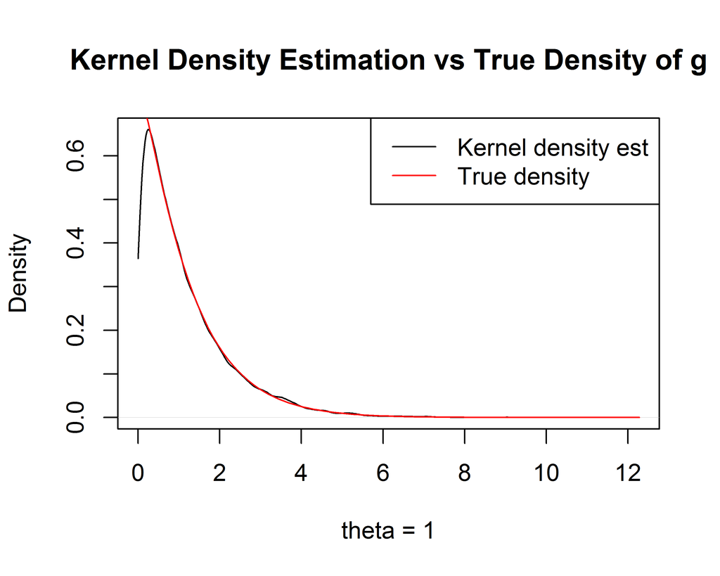

```r
GSample <- function(n, theta){
  w <- 2 * gamma(theta) / (2 * gamma(theta) + gamma(theta + 0.5)) #weight of first component
  u <- runif(n)
  x <- rgamma(n, ifelse(u <= w, theta, theta + 0.5))
  return(x)
}

GFunc <- function(theta, x){
  w <- 2 * gamma(theta) / (2 * gamma(theta) + gamma(theta + 0.5)) #weight of first component
  w * dgamma(x, shape = theta) + (1 - w) * dgamma(x, shape = theta +0.5)
}

set.seed(6218)
n <- 10000

MyPlot <- function(SampleFunc, n, param, TrueFunc){
  #param should be in the form of c(paramname = value)
  sample <- SampleFunc(n, param)
  dname <- substr(tolower(substitute(SampleFunc)), 1, 1)
  plot(density(sample, from = 0, to = max(sample)), xlab = paste(names(param), "=", param, collapse = ", "),
     main = paste("Kernel Density Estimation vs True Density of", dname))
  curve(sapply(x, function(x) TrueFunc(param, x)), from = 0, to = max(sample),
        col = "red", add = TRUE)
  legend("topright",c("Kernel density est","True density"), col = c("black", "red"), lty = 1)
}

MyPlot(GSample, n, c(theta = 1), GFunc)
```

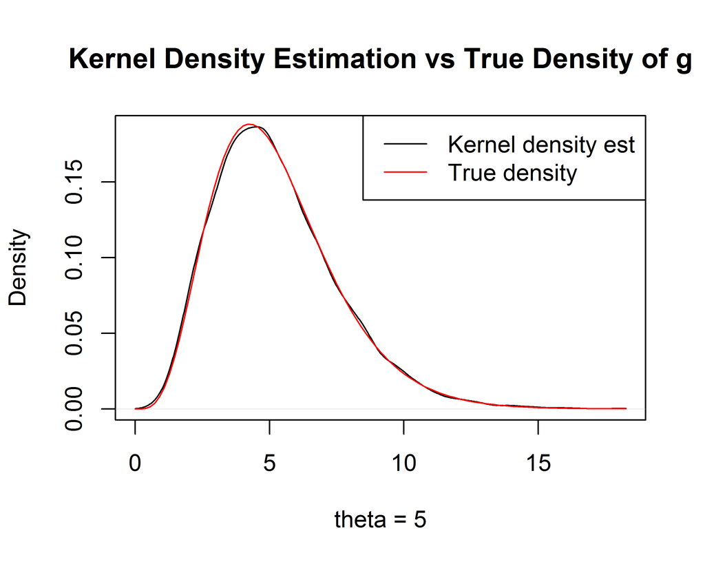

```r
MyPlot(GSample, n, c(theta = 5), GFunc)
```

We drew a sample of size $n = 10,000$ when $\theta = 1$ and $\theta = 5$. From the above two plots, we can see that in both case, the kernel density estimation of $g$ is quite closed to the true density.

## 2.3 (c)

Denote $q(x) = \sqrt{4+x}x^{\theta-1}e^{-x}$ and $h(x) = (2x^{\theta-1} + x^{\theta-1/2}) e^{-x}$. From (a) we know that $g(x) = C h(x)$. We want to find $\beta$ such that $\frac{q(x)}{h(x)} \leq \beta$ for all $x \in (0, \infty)$. Notice that
$$\begin{align}
\frac{q(x)}{h(x)} = \frac{\sqrt{4+x}x^{\theta-1}}{2x^{\theta-1} + x^{\theta-1/2}}
= \frac{\sqrt{4+x}}{2 +x^{1/2}} = \sqrt{\frac{4+x}{4+x+2x^{1/2}}} \leq 1 \text{ for all } x \in (0,\infty)
\end{align}$$

So that $\beta = 1$. Therefore, we can design the procedure to sample from $f$ as follows:

Step 1: Sample $X \sim g$ and $U \sim$ Unif$(0,1)$

Step 2: If $U > \frac{q(X)}{\beta h(X)} = \frac{\sqrt{4+X}}{2 +X^{1/2}}$, then go to Step 1; else return $X$

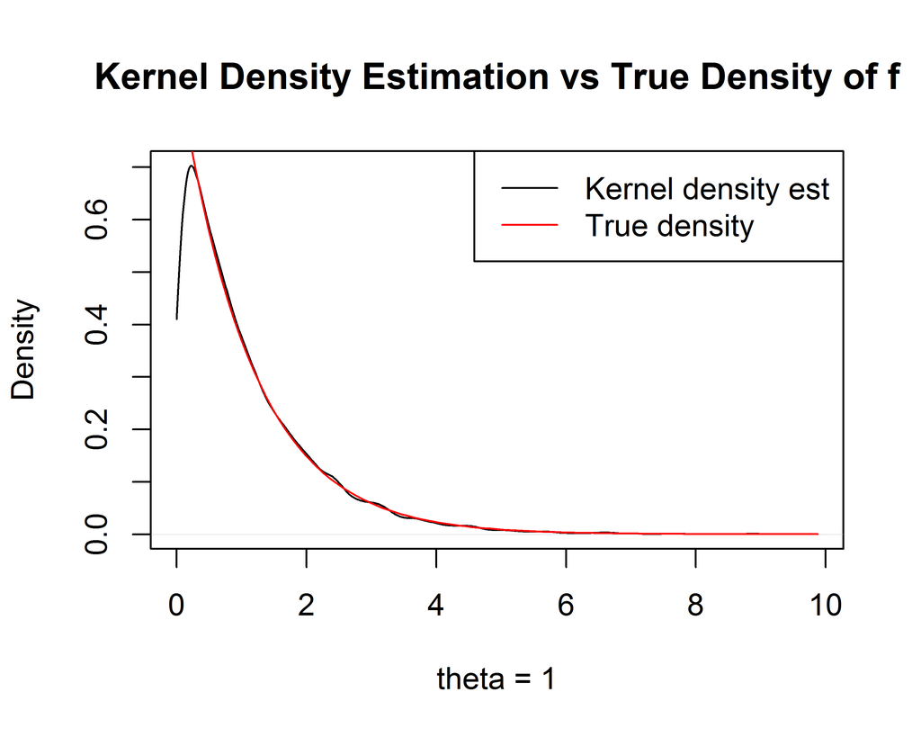

```r
FSample <- function(n, theta){
  sample <- vector(length = n)
  i <- 1
  while(i <= n){
    x <- GSample(1, theta)
    u <- runif(1)
    r <- sqrt(4 + x) / (2 + x^0.5)
    if (u <= r){
      sample[i] <- x
      i <- i + 1
    }
  }
  return(sample)
}

FFunc <- function(theta, x){
  q <- function(x) {sqrt(4 + x) * x^{theta - 1} * exp(-x)}
  return (q(x) / integrate(q, 0, Inf)$value)
}

MyPlot(FSample, n, c(theta = 1), FFunc)
```

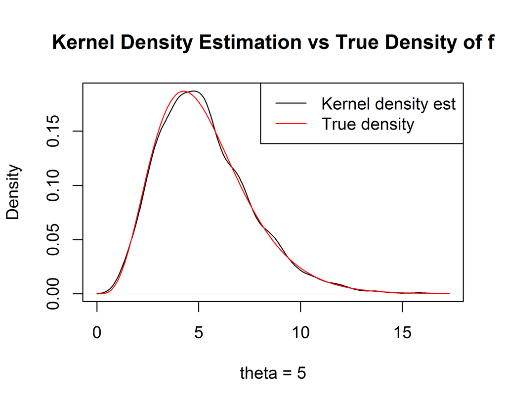

```r
MyPlot(FSample, n, c(theta = 5), FFunc)
```

We still drew a sample of size $n = 10,000$ when $\theta = 1$ and $\theta = 5$. From the above two plots, we can see that in both case, the estimated density of $f$ is quite closed to the true density.

# 3 Problem 3

## 3.1 (a)

Specify $g(x) \propto x^{\theta -1} + \sqrt{3} (1 - x)^{\beta - 1}$. We can use the same method in Problem 2 (a) to find the component distributions and their weights.
$$\begin{align}
& C \int_0^1 x^{\theta -1} + \sqrt{3} (1 - x)^{\beta - 1} dx = 1 \\
\Rightarrow \, & C B(\theta, 1) + \sqrt{3} C B(1, \beta) = 1 \\
\Rightarrow \, & C = \frac{1}{B(\theta, 1) + \sqrt{3} B(1, \beta)} \\
\end{align}$$
So that
$$\begin{align}
g(x) & = C x^{\theta -1} + \sqrt{3} (1 - x)^{\beta - 1}\\
& = \frac{B(\theta, 1)}{B(\theta, 1) + \sqrt{3} B(1, \beta)} \frac{x^{\theta -1}}{B(\theta, 1)} +
\frac{\sqrt{3} B(1, \beta)}{B(\theta, 1) + \sqrt{3} B(1, \beta)} \frac{(1 - x)^{\beta - 1}}{B(1, \beta)}
\end{align}$$

where $\frac{x^{\theta -1}}{B(\theta, 1)}$ is the p.d.f. of Beta$(\theta,1)$ and $\frac{(1 - x)^{\beta - 1}}{B(1, \beta)}$ is the p.d.f. of Beta$(1,\beta)$. Therefore, $g$ is a mixture of Beta distributions. The first component distribution is Beta$(\theta,1)$ with weight $\frac{B(\theta, 1)}{B(\theta, 1) + \sqrt{3} B(1, \beta)}$, and the second component distribution is Beta$(1, \beta)$ with weight $\frac{\sqrt{3} B(1, \beta)}{B(\theta, 1) + \sqrt{3} B(1, \beta)}$.

We first lay out the procedure to sample from $g$:

Step 1: Sample $U \sim$ Unif$(0,1)$

Step 2: If $U \leq \frac{B(\theta, 1)}{B(\theta, 1) + \sqrt{3} B(1, \beta)}$, then sample $X \sim$ Beta$(\theta,1)$; else sample $X \sim$ Beta$(1, \beta)$

Denote $q(x) = \frac{x^{\theta -1}}{1+x^2} + \sqrt{2+x^2} (1 -x)^{\beta-1}$ and $h(x) = x^{\theta -1} + \sqrt{3} (1 - x)^{\beta - 1}$. We want to find $\beta$ such that $\frac{q(x)}{h(x)} \leq \beta$ for all $x \in (0, 1)$. Since $\frac{q(x)}{h(x)} \leq 1$, $\beta = 1$. Therefore, we can design the procedure to sample from $f$ as follows:

Step 1: Sample $X \sim g$ and $U \sim$ Unif$(0,1)$

Step 2: If $U > \frac{q(X)}{h(X)}$, then go to Step 1; else return $X$

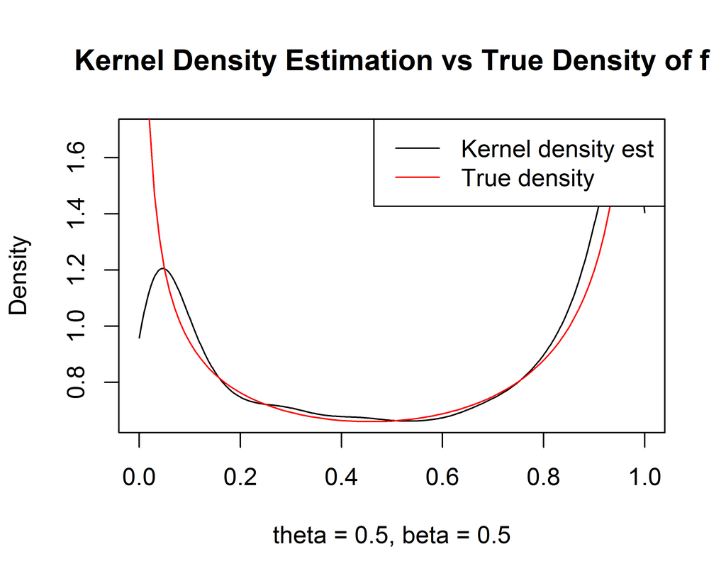

```r
GSample2 <- function(n, param){
  #param should be in the form of c(theta, beta)
  w <- beta(param[1], 1) / (beta(param[1], 1) + sqrt(3) * beta(1, param[2])) #weight of first component
  u <- runif(n)
  x <- rbeta(n, ifelse(u <= w, param[1], 1), ifelse(u <= w, 1, param[2]))
  return(x)
}

GFunc2 <- function(param, x){
  w <- beta(param[1], 1) / (beta(param[1], 1) + sqrt(3) * beta(1, param[2])) #weight of first component
  w * dbeta(x, param[1], 1) + (1 - w) * dbeta(x, 1, param[2])
}

QFunc <- function(param, x){
  #param should be in the form of c(theta, beta)
  x^{param[1] - 1} / (1 + x^2) + sqrt(2 + x^2) * (1 - x)^{param[2] - 1}
}

HFunc <- function(param, x){
  #param should be in the form of c(theta, beta)
  x^{param[1] - 1} + sqrt(3) * (1 - x)^{param[2] - 1}
}

FSample2 <- function(n, param){
  #param should be in the form of c(theta, beta)
  sample <- vector(length = n)
  i <- 1
  while(i <= n){
    x <- GSample2(1, param)
    u <- runif(1)
    r <- QFunc(param, x) / HFunc(param, x)
    if (u <= r){
      sample[i] <- x
      i <- i + 1
    }
  }
  return(sample)
}

FFunc2 <- function(param, x){
  #param should be in the form of c(theta, beta)
  q <- function(x) {QFunc(param, x)}
  return (q(x) / integrate(q, 0, 1)$value)
}

MyPlot(FSample2, n, c(theta = 0.5, beta = 0.5), FFunc2)
```

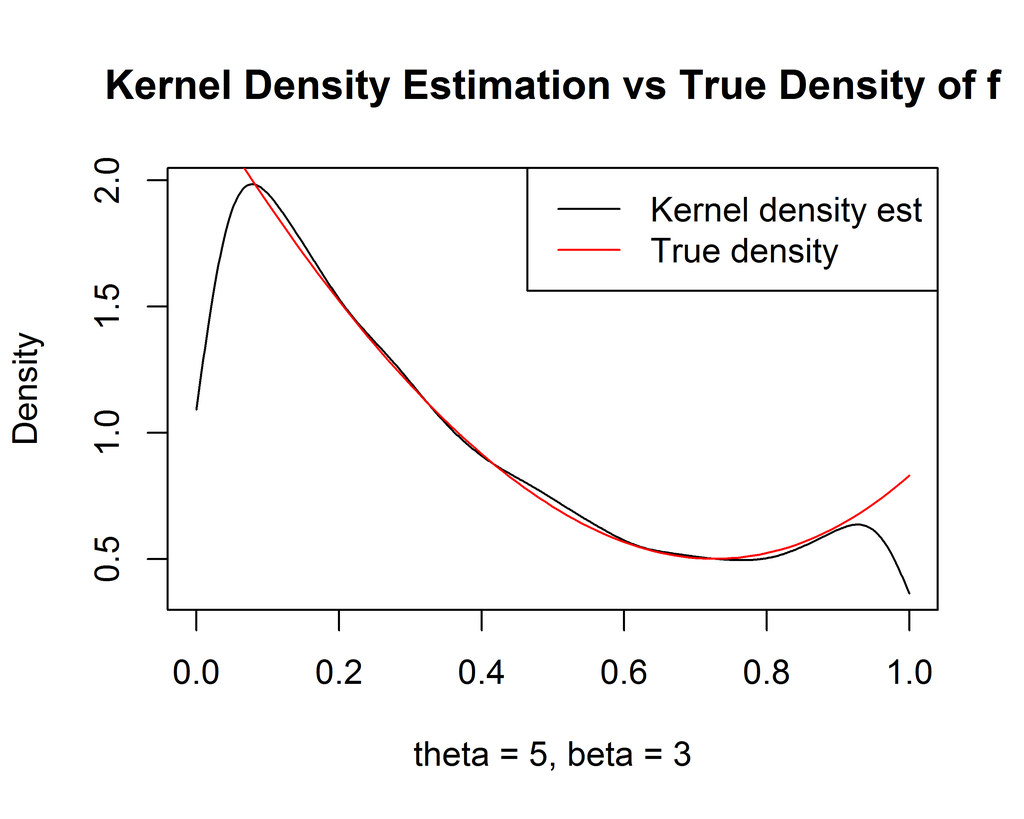

```r
MyPlot(FSample2, n, c(theta = 5, beta = 3), FFunc2)
```

We drew a sample of size $n = 10,000$ when $\theta = 0.5, \beta = 0.5$ and $\theta = 5, \beta = 3$. From the above two plots, we can see that in both case, the estimated density of $f$ is quite closed to the true density in the middle part.

## 3.2 (b)

Denote $q_1(x) = \frac{x^{\theta - 1}}{1+x^2}, q_2(x) = \sqrt{2 + x^2} (1-x)^{\beta - 1}$. When dealing with two components separately, we can simply use $g_1(x) = \frac{x^{\theta - 1}}{B(\theta, 1)}$, which is Beta$(\theta, 1)$; and $g_2(x) = \frac{(1-x)^{\beta - 1}}{B(1, \beta)}$, which is Beta$(1, \beta)$. So that
$$\begin{align}
\alpha_1 & = \sup \frac{q_1(x)}{g_1(x)}= \sup \frac{B(\theta, 1)}{1 + x^2} = B(\theta, 1)\\
\alpha_2 & = \sup \frac{q_2(x)}{g_2(x)}= \sup \sqrt{2 + x^2} B(1, \beta) = \sqrt{3} B(1, \beta)
\end{align}$$

Therefore, design the procedure to sample from $f$ in this way as follows:

Step 1: Sample $K \sim$ Unif$(0,1)$ and $U \sim$ Unif$(0,1)$ independently

Step 2: If $K \leq \frac{\alpha_1}{\alpha_1 + \alpha_2}= \frac{B(\theta, 1)}{B(\theta, 1) + \sqrt{3} B(1, \beta)}$, then

sample $X \sim g_1$, i.e., Beta$(\theta, 1)$, and calculate $r = \frac{q_1(X)}{\alpha_1 g_1(X)} = \frac{1}{1 + x^2}$;

else sample $X \sim g_2$, i.e., Beta$(1, \beta)$, and calculate $r = \frac{q_2(X)}{\alpha_2 g_2(X)} = \sqrt{\frac{2 + x^2}{3}}$

Step 3: If $U > r$, then go to Step 1; else return $X$

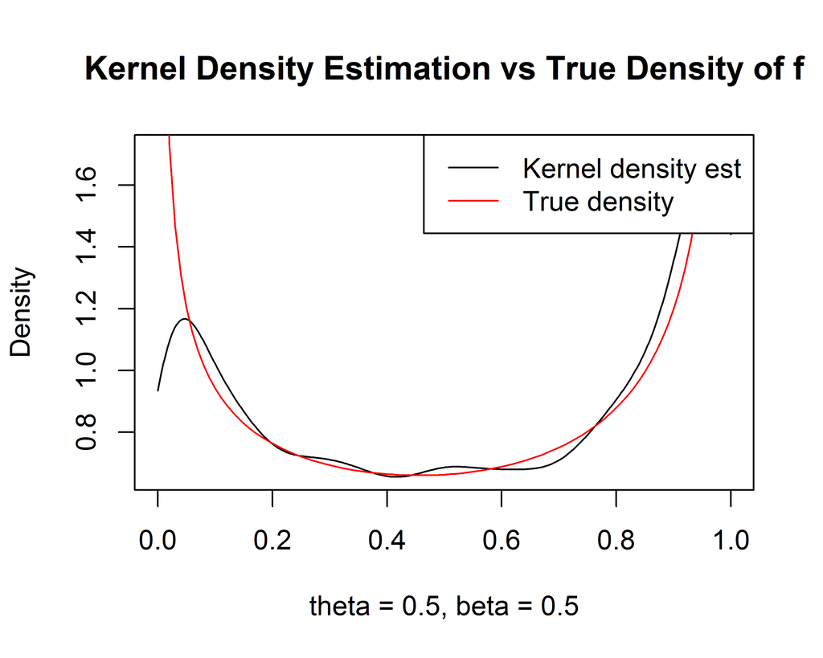

```r
FSample3 <- function(n, param){
  #param should be in the form of c(theta, beta)
  sample <- vector(length = n)
  i <- 1
  w <- beta(param[1], 1) / (beta(param[1], 1) + sqrt(3) * beta(1, param[2]))
  while(i <= n){
    k <- runif(1)
    u <- runif(1)
    if (k <= w){
      x <- rbeta(1, param[1], 1)
      r <- 1/ (1 + x^2)
    }else{
      x <- rbeta(1, 1, param[2])
      r <- sqrt((2 + x^2) / 3)
    }
    if (u <= r){
      sample[i] <- x
      i <- i + 1
    }
  }
  return(sample)
}

MyPlot(FSample3, n, c(theta = 0.5, beta = 0.5), FFunc2)
```

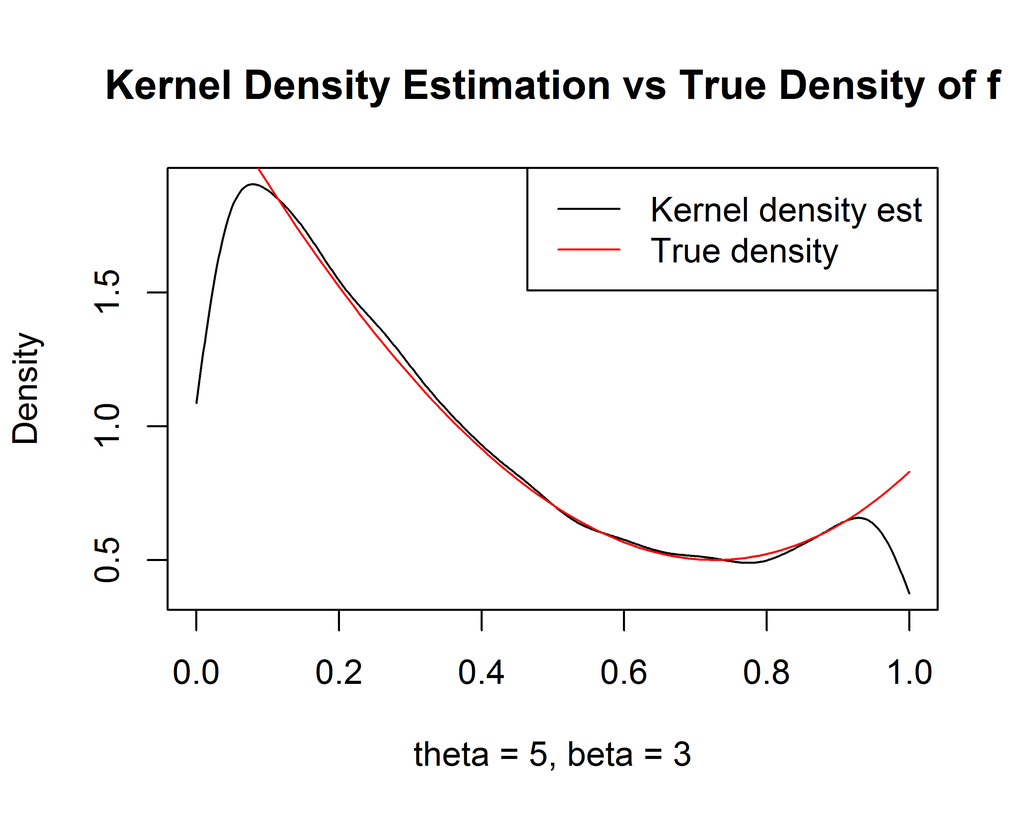

```r
MyPlot(FSample3, n, c(theta = 5, beta = 3), FFunc2)
```